# Insights from WeRateDogs Data

**WeRateDogs** is one of the more popular Twitter accounts with 7.42 million at the time of writing. This account is devoted to, you guessed it, rating dogs. Here is a sample tweet:

[figure not shown]

You can probably see the appeal of the account especially if you're a dog person. Even if you aren't particularly fond of dogs, you have to admit that a lot of these dogs are pretty darn cute. Tweets made by the account follow a similar format with a description of the dog, a score and some form of media (usually a picture) depicting the dog.

In this article, I'll be taking a look at the archived tweets graciously provided by **WeRateDogs** beginning from the account's creation up to around August of 2017. The goal is to illustrate the process of gaining insight into your data after you've gone through the whole wrangling process. In addition to the archived tweet data, I've also been provided with the prediction results of a machine learning algorithm trained on pictures from a sample of the archived tweets which I used to supplement the archived tweet data.

I've already performed the tedious but necessary task of wrangling the data so I'll jump right into sharing some of the insights I've gained from the data which I've grouped into two categories: insights about the tweets themselves and general insights about the **WeRateDogs** account. Before that, I'll import the necessary libraries and let you take a peek at the cleaned data.

```python
import pandas as pd
import numpy as np
import matplotlib.pyplot as plt
import seaborn as sns
import itertools
import warnings

# Enable inline plotting, use seaborn styling on plots, and ignore matplotlib and seaborn warnings
%matplotlib inline
sns.set()
warnings.filterwarnings('ignore')

# Import cleaned data and display it
twitter_archive_master = pd.read_csv('twitter-archive-master.csv')
twitter_archive_master
```

|  | tweet_id | in_reply_to_status_id | in_reply_to_user_id | timestamp | source | text | expanded_urls | rating_numerator | rating_denominator | name | dog_type | retweet_count | favorite_count | dog_breed |
| --- | --- | --- | --- | --- | --- | --- | --- | --- | --- | --- | --- | --- | --- | --- |
| 0 | 892420643555336193 | NaN | NaN | 2017-08-01 16:23:56 | Twitter for iPhone | This is Phineas. He's a mystical boy. Only eve... | https://twitter.com/dog_rates/status/892420643... | 13.0 | 10 | Phineas | NaN | 8426.0 | 38368.0 | NaN |
| 1 | 892177421306343426 | NaN | NaN | 2017-08-01 00:17:27 | Twitter for iPhone | This is Tilly. She's just checking pup on you.... | https://twitter.com/dog_rates/status/892177421... | 13.0 | 10 | Tilly | NaN | 6208.0 | 32881.0 | Chihuahua |
| 2 | 891815181378084864 | NaN | NaN | 2017-07-31 00:18:03 | Twitter for iPhone | This is Archie. He is a rare Norwegian Pouncin... | https://twitter.com/dog_rates/status/891815181... | 12.0 | 10 | Archie | NaN | 4107.0 | 24776.0 | Chihuahua |
| 3 | 891689557279858688 | NaN | NaN | 2017-07-30 15:58:51 | Twitter for iPhone | This is Darla. She commenced a snooze mid meal... | https://twitter.com/dog_rates/status/891689557... | 13.0 | 10 | Darla | NaN | 8542.0 | 41710.0 | Labrador retriever |
| 4 | 891327558926688256 | NaN | NaN | 2017-07-29 16:00:24 | Twitter for iPhone | This is Franklin. He would like you to stop ca... | https://twitter.com/dog_rates/status/891327558... | 12.0 | 10 | Franklin | NaN | 9280.0 | 39884.0 | basset |
| 5 | 891087950875897856 | NaN | NaN | 2017-07-29 00:08:17 | Twitter for iPhone | Here we have a majestic great white breaching ... | https://twitter.com/dog_rates/status/891087950... | 13.0 | 10 | NaN | NaN | 3076.0 | 20018.0 | Chesapeake Bay retriever |
| 6 | 890971913173991426 | NaN | NaN | 2017-07-28 16:27:12 | Twitter for iPhone | Meet Jax. He enjoys ice cream so much he gets ... | https://gofundme.com/ydvmve-surgery-for-jax,ht... | 13.0 | 10 | Jax | NaN | 2044.0 | 11717.0 | Appenzeller |
| 7 | 890729181411237888 | NaN | NaN | 2017-07-28 00:22:40 | Twitter for iPhone | When you watch your owner call another dog a g... | https://twitter.com/dog_rates/status/890729181... | 13.0 | 10 | NaN | NaN | 18686.0 | 64781.0 | Pomeranian |
| 8 | 890609185150312448 | NaN | NaN | 2017-07-27 16:25:51 | Twitter for iPhone | This is Zoey. She doesn't want to be one of th... | https://twitter.com/dog_rates/status/890609185... | 13.0 | 10 | Zoey | NaN | 4220.0 | 27530.0 | Irish terrier |
| 9 | 890240255349198849 | NaN | NaN | 2017-07-26 15:59:51 | Twitter for iPhone | This is Cassie. She is a college pup. Studying... | https://twitter.com/dog_rates/status/890240255... | 14.0 | 10 | Cassie | doggo | 7318.0 | 31592.0 | Pembroke |
| 10 | 890006608113172480 | NaN | NaN | 2017-07-26 00:31:25 | Twitter for iPhone | This is Koda. He is a South Australian decksha... | https://twitter.com/dog_rates/status/890006608... | 13.0 | 10 | Koda | NaN | 7257.0 | 30342.0 | Samoyed |
| 11 | 889880896479866881 | NaN | NaN | 2017-07-25 16:11:53 | Twitter for iPhone | This is Bruno. He is a service shark. Only get... | https://twitter.com/dog_rates/status/889880896... | 13.0 | 10 | Bruno | NaN | 4925.0 | 27499.0 | French bulldog |
| 12 | 889665388333682689 | NaN | NaN | 2017-07-25 01:55:32 | Twitter for iPhone | Here's a puppo that seems to be on the fence a... | https://twitter.com/dog_rates/status/889665388... | 13.0 | 10 | NaN | puppo | 9957.0 | 47618.0 | Pembroke |
| 13 | 889638837579907072 | NaN | NaN | 2017-07-25 00:10:02 | Twitter for iPhone | This is Ted. He does his best. Sometimes that'... | https://twitter.com/dog_rates/status/889638837... | 12.0 | 10 | Ted | NaN | 4493.0 | 26884.0 | French bulldog |
| 14 | 889531135344209921 | NaN | NaN | 2017-07-24 17:02:04 | Twitter for iPhone | This is Stuart. He's sporting his favorite fan... | https://twitter.com/dog_rates/status/889531135... | 13.0 | 10 | Stuart | puppo | 2212.0 | 14940.0 | golden retriever |
| 15 | 889278841981685760 | NaN | NaN | 2017-07-24 00:19:32 | Twitter for iPhone | This is Oliver. You're witnessing one of his m... | https://twitter.com/dog_rates/status/889278841... | 13.0 | 10 | Oliver | NaN | 5362.0 | 25037.0 | whippet |
| 16 | 888917238123831296 | NaN | NaN | 2017-07-23 00:22:39 | Twitter for iPhone | This is Jim. He found a fren. Taught him how t... | https://twitter.com/dog_rates/status/888917238... | 12.0 | 10 | Jim | NaN | 4451.0 | 28791.0 | golden retriever |
| 17 | 888804989199671297 | NaN | NaN | 2017-07-22 16:56:37 | Twitter for iPhone | This is Zeke. He has a new stick. Very proud o... | https://twitter.com/dog_rates/status/888804989... | 13.0 | 10 | Zeke | NaN | 4277.0 | 25325.0 | golden retriever |
| 18 | 888554962724278272 | NaN | NaN | 2017-07-22 00:23:06 | Twitter for iPhone | This is Ralphus. He's powering up. Attempting ... | https://twitter.com/dog_rates/status/888554962... | 13.0 | 10 | Ralphus | NaN | 3538.0 | 19675.0 | Siberian husky |
| 19 | 888078434458587136 | NaN | NaN | 2017-07-20 16:49:33 | Twitter for iPhone | This is Gerald. He was just told he didn't get... | https://twitter.com/dog_rates/status/888078434... | 12.0 | 10 | Gerald | NaN | 3461.0 | 21529.0 | French bulldog |
| 20 | 887705289381826560 | NaN | NaN | 2017-07-19 16:06:48 | Twitter for iPhone | This is Jeffrey. He has a monopoly on the pool... | https://twitter.com/dog_rates/status/887705289... | 13.0 | 10 | Jeffrey | NaN | 5331.0 | 29844.0 | basset |
| 21 | 887517139158093824 | NaN | NaN | 2017-07-19 03:39:09 | Twitter for iPhone | I've yet to rate a Venezuelan Hover Wiener. Th... | https://twitter.com/dog_rates/status/887517139... | 14.0 | 10 | NaN | NaN | 11543.0 | 45770.0 | NaN |
| 22 | 887473957103951883 | NaN | NaN | 2017-07-19 00:47:34 | Twitter for iPhone | This is Canela. She attempted some fancy porch... | https://twitter.com/dog_rates/status/887473957... | 13.0 | 10 | Canela | NaN | 18012.0 | 68378.0 | Pembroke |
| 23 | 887343217045368832 | NaN | NaN | 2017-07-18 16:08:03 | Twitter for iPhone | You may not have known you needed to see this ... | https://twitter.com/dog_rates/status/887343217... | 13.0 | 10 | NaN | NaN | 10297.0 | 33325.0 | Mexican hairless |
| 24 | 887101392804085760 | NaN | NaN | 2017-07-18 00:07:08 | Twitter for iPhone | This... is a Jubilant Antarctic House Bear. We... | https://twitter.com/dog_rates/status/887101392... | 12.0 | 10 | NaN | NaN | 5902.0 | 30238.0 | Samoyed |
| 25 | 886983233522544640 | NaN | NaN | 2017-07-17 16:17:36 | Twitter for iPhone | This is Maya. She's very shy. Rarely leaves he... | https://twitter.com/dog_rates/status/886983233... | 13.0 | 10 | Maya | NaN | 7699.0 | 34794.0 | Chihuahua |
| 26 | 886736880519319552 | NaN | NaN | 2017-07-16 23:58:41 | Twitter for iPhone | This is Mingus. He's a wonderful father to his... | https://www.gofundme.com/mingusneedsus,https:/... | 13.0 | 10 | Mingus | NaN | 3256.0 | 11929.0 | kuvasz |
| 27 | 886680336477933568 | NaN | NaN | 2017-07-16 20:14:00 | Twitter for iPhone | This is Derek. He's late for a dog meeting. 13... | https://twitter.com/dog_rates/status/886680336... | 13.0 | 10 | Derek | NaN | 4417.0 | 22191.0 | NaN |
| 28 | 886366144734445568 | NaN | NaN | 2017-07-15 23:25:31 | Twitter for iPhone | This is Roscoe. Another pupper fallen victim t... | https://twitter.com/dog_rates/status/886366144... | 12.0 | 10 | Roscoe | pupper | 3167.0 | 20970.0 | French bulldog |
| 29 | 886267009285017600 | 8.862664e+17 | 2.281182e+09 | 2017-07-15 16:51:35 | Twitter for iPhone | @NonWhiteHat @MayhewMayhem omg hello tanner yo... | NaN | 12.0 | 10 | NaN | NaN | 4.0 | 115.0 | NaN |
| ... | ... | ... | ... | ... | ... | ... | ... | ... | ... | ... | ... | ... | ... | ... |
| 2144 | 666411507551481857 | NaN | NaN | 2015-11-17 00:24:19 | Twitter for iPhone | This is quite the dog. Gets really excited whe... | https://twitter.com/dog_rates/status/666411507... | 2.0 | 10 | NaN | NaN | 324.0 | 441.0 | NaN |
| 2145 | 666407126856765440 | NaN | NaN | 2015-11-17 00:06:54 | Twitter for iPhone | This is a southern Vesuvius bumblegruff. Can d... | https://twitter.com/dog_rates/status/666407126... | 7.0 | 10 | NaN | NaN | 40.0 | 108.0 | black-and-tan coonhound |
| 2146 | 666396247373291520 | NaN | NaN | 2015-11-16 23:23:41 | Twitter for iPhone | Oh goodness. A super rare northeast Qdoba kang... | https://twitter.com/dog_rates/status/666396247... | 9.0 | 10 | NaN | NaN | 84.0 | 167.0 | Chihuahua |
| 2147 | 666373753744588802 | NaN | NaN | 2015-11-16 21:54:18 | Twitter for iPhone | Those are sunglasses and a jean jacket. 11/10 ... | https://twitter.com/dog_rates/status/666373753... | 11.0 | 10 | NaN | NaN | 92.0 | 187.0 | soft-coated wheaten terrier |
| 2148 | 666362758909284353 | NaN | NaN | 2015-11-16 21:10:36 | Twitter for iPhone | Unique dog here. Very small. Lives in containe... | https://twitter.com/dog_rates/status/666362758... | 6.0 | 10 | NaN | NaN | 566.0 | 774.0 | NaN |
| 2149 | 666353288456101888 | NaN | NaN | 2015-11-16 20:32:58 | Twitter for iPhone | Here we have a mixed Asiago from the Galápagos... | https://twitter.com/dog_rates/status/666353288... | 8.0 | 10 | NaN | NaN | 72.0 | 219.0 | malamute |
| 2150 | 666345417576210432 | NaN | NaN | 2015-11-16 20:01:42 | Twitter for iPhone | Look at this jokester thinking seat belt laws ... | https://twitter.com/dog_rates/status/666345417... | 10.0 | 10 | NaN | NaN | 135.0 | 293.0 | golden retriever |
| 2151 | 666337882303524864 | NaN | NaN | 2015-11-16 19:31:45 | Twitter for iPhone | This is an extremely rare horned Parthenon. No... | https://twitter.com/dog_rates/status/666337882... | 9.0 | 10 | NaN | NaN | 90.0 | 197.0 | Newfoundland |
| 2152 | 666293911632134144 | NaN | NaN | 2015-11-16 16:37:02 | Twitter for iPhone | This is a funny dog. Weird toes. Won't come do... | https://twitter.com/dog_rates/status/666293911... | 3.0 | 10 | NaN | NaN | 352.0 | 498.0 | NaN |
| 2153 | 666287406224695296 | NaN | NaN | 2015-11-16 16:11:11 | Twitter for iPhone | This is an Albanian 3 1/2 legged Episcopalian... | https://twitter.com/dog_rates/status/666287406... | 1.0 | 2 | NaN | NaN | 64.0 | 146.0 | Maltese dog |
| 2154 | 666273097616637952 | NaN | NaN | 2015-11-16 15:14:19 | Twitter for iPhone | Can take selfies 11/10 https://t.co/ws2AMaNwPW | https://twitter.com/dog_rates/status/666273097... | 11.0 | 10 | NaN | NaN | 76.0 | 174.0 | Italian greyhound |
| 2155 | 666268910803644416 | NaN | NaN | 2015-11-16 14:57:41 | Twitter for iPhone | Very concerned about fellow dog trapped in com... | https://twitter.com/dog_rates/status/666268910... | 10.0 | 10 | NaN | NaN | 35.0 | 102.0 | NaN |
| 2156 | 666104133288665088 | NaN | NaN | 2015-11-16 04:02:55 | Twitter for iPhone | Not familiar with this breed. No tail (weird).... | https://twitter.com/dog_rates/status/666104133... | 1.0 | 10 | NaN | NaN | 6530.0 | 14222.0 | NaN |
| 2157 | 666102155909144576 | NaN | NaN | 2015-11-16 03:55:04 | Twitter for iPhone | Oh my. Here you are seeing an Adobe Setter giv... | https://twitter.com/dog_rates/status/666102155... | 11.0 | 10 | NaN | NaN | 12.0 | 80.0 | English setter |
| 2158 | 666099513787052032 | NaN | NaN | 2015-11-16 03:44:34 | Twitter for iPhone | Can stand on stump for what seems like a while... | https://twitter.com/dog_rates/status/666099513... | 8.0 | 10 | NaN | NaN | 67.0 | 153.0 | Lhasa |
| 2159 | 666094000022159362 | NaN | NaN | 2015-11-16 03:22:39 | Twitter for iPhone | This appears to be a Mongolian Presbyterian mi... | https://twitter.com/dog_rates/status/666094000... | 9.0 | 10 | NaN | NaN | 73.0 | 163.0 | bloodhound |
| 2160 | 666082916733198337 | NaN | NaN | 2015-11-16 02:38:37 | Twitter for iPhone | Here we have a well-established sunblockerspan... | https://twitter.com/dog_rates/status/666082916... | 6.0 | 10 | NaN | NaN | 44.0 | 117.0 | pug |
| 2161 | 666073100786774016 | NaN | NaN | 2015-11-16 01:59:36 | Twitter for iPhone | Let's hope this flight isn't Malaysian (lol). ... | https://twitter.com/dog_rates/status/666073100... | 10.0 | 10 | NaN | NaN | 163.0 | 320.0 | Walker hound |
| 2162 | 666071193221509120 | NaN | NaN | 2015-11-16 01:52:02 | Twitter for iPhone | Here we have a northern speckled Rhododendron.... | https://twitter.com/dog_rates/status/666071193... | 9.0 | 10 | NaN | NaN | 60.0 | 146.0 | Gordon setter |
| 2163 | 666063827256086533 | NaN | NaN | 2015-11-16 01:22:45 | Twitter for iPhone | This is the happiest dog you will ever see. Ve... | https://twitter.com/dog_rates/status/666063827... | 10.0 | 10 | NaN | NaN | 216.0 | 471.0 | golden retriever |
| 2164 | 666058600524156928 | NaN | NaN | 2015-11-16 01:01:59 | Twitter for iPhone | Here is the Rand Paul of retrievers folks! He'... | https://twitter.com/dog_rates/status/666058600... | 8.0 | 10 | NaN | NaN | 57.0 | 111.0 | miniature poodle |
| 2165 | 666057090499244032 | NaN | NaN | 2015-11-16 00:55:59 | Twitter for iPhone | My oh my. This is a rare blond Canadian terrie... | https://twitter.com/dog_rates/status/666057090... | 9.0 | 10 | NaN | NaN | 141.0 | 295.0 | golden retriever |
| 2166 | 666055525042405380 | NaN | NaN | 2015-11-16 00:49:46 | Twitter for iPhone | Here is a Siberian heavily armored polar bear ... | https://twitter.com/dog_rates/status/666055525... | 10.0 | 10 | NaN | NaN | 247.0 | 433.0 | chow |
| 2167 | 666051853826850816 | NaN | NaN | 2015-11-16 00:35:11 | Twitter for iPhone | This is an odd dog. Hard on the outside but lo... | https://twitter.com/dog_rates/status/666051853... | 2.0 | 10 | NaN | NaN | 843.0 | 1209.0 | NaN |
| 2168 | 666050758794694657 | NaN | NaN | 2015-11-16 00:30:50 | Twitter for iPhone | This is a truly beautiful English Wilson Staff... | https://twitter.com/dog_rates/status/666050758... | 10.0 | 10 | NaN | NaN | 59.0 | 132.0 | Bernese mountain dog |
| 2169 | 666049248165822465 | NaN | NaN | 2015-11-16 00:24:50 | Twitter for iPhone | Here we have a 1949 1st generation vulpix. Enj... | https://twitter.com/dog_rates/status/666049248... | 5.0 | 10 | NaN | NaN | 40.0 | 109.0 | miniature pinscher |
| 2170 | 666044226329800704 | NaN | NaN | 2015-11-16 00:04:52 | Twitter for iPhone | This is a purebred Piers Morgan. Loves to Netf... | https://twitter.com/dog_rates/status/666044226... | 6.0 | 10 | NaN | NaN | 140.0 | 298.0 | Rhodesian ridgeback |
| 2171 | 666033412701032449 | NaN | NaN | 2015-11-15 23:21:54 | Twitter for iPhone | Here is a very happy pup. Big fan of well-main... | https://twitter.com/dog_rates/status/666033412... | 9.0 | 10 | NaN | NaN | 44.0 | 125.0 | German shepherd |
| 2172 | 666029285002620928 | NaN | NaN | 2015-11-15 23:05:30 | Twitter for iPhone | This is a western brown Mitsubishi terrier. Up... | https://twitter.com/dog_rates/status/666029285... | 7.0 | 10 | NaN | NaN | 47.0 | 128.0 | redbone |
| 2173 | 666020888022790149 | NaN | NaN | 2015-11-15 22:32:08 | Twitter for iPhone | Here we have a Japanese Irish Setter. Lost eye... | https://twitter.com/dog_rates/status/666020888... | 8.0 | 10 | NaN | NaN | 508.0 | 2553.0 | Welsh springer spaniel |

2174 rows × 14 columns

## Tweet insights

### Most common dog breeds

One of the first things I was interested in knowing is: what are the most common dog breeds that appear in the tweets made by **WeRateDogs**? Since the cleaned dataset already contains the correct predictions made by the algorithm, I've been spared having to trawl through the over 2000 pictures and identify the breed of each dog. I should mention that not every tweet in the dataset has a corresponding dog breed. This is to be expected given the nature of machine learning algorithms and the process of training them. This isn't something that I need to be too concerned about as the total amount of correct predictions made by the algorithm is sufficient for the insight gained here to be meaningful.

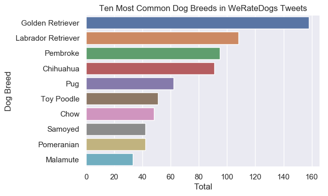

```python
# Plot counts of the 10 most common dog breeds
top_breeds = (twitter_archive_master.dog_breed.value_counts()
              .head(10)
              .to_frame()
              .reset_index()
              .rename(columns={'index': 'dog_breed', 'dog_breed': 'total'}))
top_breeds['dog_breed'] = top_breeds['dog_breed'].str.title()
plt.figure(dpi=100);
ax = sns.barplot(x='total', y='dog_breed', data=top_breeds);
ax.set_title('Ten Most Common Dog Breeds in WeRateDogs Tweets');
ax.set_ylabel('Dog Breed');
ax.set_xlabel('Total');
```

Here I can see that the dog breed that appears most often in **WeRateDogs** tweets even compared to the rest of the most common dog breeds is the Golden Retriever. In fact, it seems that the Golden Retriever is far and away the most common dog breed. Given the **WeRateDogs** account's huge following, this could be an indication of the overall popularity of not only the breeds shown in the chart but the other breeds in the sample as well. This is, of course, assuming that the people who follow **WeRateDogs** is representative of dog owners as a whole.

### Most common dog type

One of the more charming and unique aspects of **WeRateDogs** is the lingo that has developed around the account. One of the more common and fun bits of this lingo is how people refer to dogs. Dogs are called 'pupper', 'puppo', or 'doggo' based on how old the dog is with 'pupper' being used for puppies, 'doggo' for adult dogs, and 'puppo' for dogs in a stage of development between puppy and adult. There is also the word 'floofer' used to describe dogs of any age with a particularly fluffy coat. I'd like to know which of these words appears the most in the archived tweets.

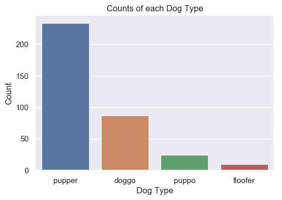

```python
# Extract separate dog types
dog_type_mask = twitter_archive_master['dog_type'].notnull()
dog_type_raw = twitter_archive_master.dog_type.loc[dog_type_mask].str.split(',').tolist()
dog_type = list(map(lambda x: x.strip(), itertools.chain.from_iterable(dog_type_raw)))
dog_type = np.array(dog_type)

# Plot counts of each dog type
plot_category_order = ['pupper', 'doggo', 'puppo', 'floofer']
plt.figure(dpi=100);
ax = sns.countplot(x=dog_type, order=plot_category_order);
ax.set_title('Counts of each Dog Type');
ax.set_ylabel('Count');
ax.set_xlabel('Dog Type');
```

It would appear that the most commonly used term is 'pupper' indicating that the majority of the dogs shown in **WeRateDogs** are puppies. Although I didn't expicitly calculate it the total number of archived tweets is 2174. The total number of dog types is clearly nowhere near this number. Including the tweets that don't contain the type of dog will give a more accurate frequency count.

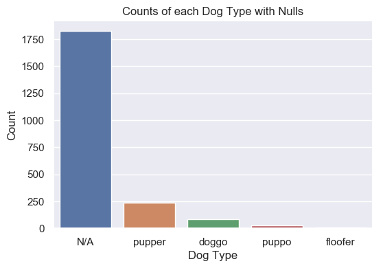

```python
# Extract separate dog types with nulls
dog_type_nulls_raw = twitter_archive_master['dog_type'].fillna('N/A').str.split(',').tolist()
dog_type_nulls = list(map(lambda x: x.strip(), itertools.chain.from_iterable(dog_type_nulls_raw)))
dog_type_nulls = np.array(dog_type_nulls)

# Plot counts of each dog type with nulls
plot_category_order_nulls = ['N/A', 'pupper', 'doggo', 'puppo', 'floofer']
plt.figure(dpi=100);
ax = sns.countplot(x=dog_type_nulls, order=plot_category_order_nulls);
ax.set_title('Counts of each Dog Type with Nulls');
ax.set_ylabel('Count');
ax.set_xlabel('Dog Type');
```

From the chart it's abundantly clear that the overwhelming majority of the tweets do not refer to the dogs using any of these words. Thus, I actually don't have a good idea of the general age of the dogs shown in the tweets of **WeRateDogs**.

### Most common scores

Another unique aspect of **WeRateDogs** and one of the biggest draws is the scoring system where the numerator is usually larger than the denominator. Here I'll see which scores are most commonly handed out.

```python
twitter_archive_master['score'] = twitter_archive_master['rating_numerator'].astype(str).str.replace('\.0$', '', regex=True) + \
                                  '/' + twitter_archive_master['rating_denominator'].astype(str)
twitter_archive_master.score.value_counts()
```

```
12/10       500
10/10       442
11/10       425
13/10       308
9/10        155
8/10         98
7/10         53
14/10        43
5/10         34
6/10         32
3/10         19
4/10         15
2/10          9
1/10          7
4/20          2
420/10        2
0/10          2
204/170       1
144/120       1
84/70         1
17/10         1
121/110       1
60/50         1
45/50         1
776/10        1
182/10        1
11.27/10      1
9.75/10       1
50/50         1
666/10        1
9/11          1
13.5/10       1
165/150       1
88/80         1
80/80         1
7/11          1
24/7          1
143/130       1
44/40         1
11.26/10      1
99/90         1
15/10         1
1/2           1
9.5/10        1
20/16         1
Name: score, dtype: int64
```

## WeRateDogs account insights

### Total tweets per month

One of the really nice things about the archived tweets is that they come with timestamps. With imestamps, you have access to a new dimension of analysis as you're able to view trends over periods of time. I'll use the provided timestamps to gain some insight into how often **WeRateDogs** posts tweets. Keep in mind that the account was started in November 15, 2015.

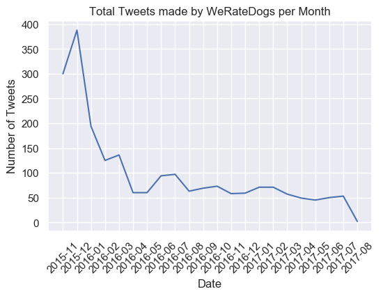

```python
# Prepare tweet_archive for plotting
twitter_archive_master['timestamp'] = pd.to_datetime(twitter_archive_master['timestamp'])
twitter_archive_master['year_month_date'] = twitter_archive_master['timestamp'].dt.year.astype(str) + '-' + \
                                            twitter_archive_master['timestamp'].dt.month.astype(str).str.pad(2, fillchar='0')
twitter_archive_master['is_tweet'] = np.where(twitter_archive_master.tweet_id.notnull(), 1, 0)

# Get required data from twitter_archive
twitter_archive_monthly_tweets = twitter_archive_master.groupby('year_month_date').is_tweet.sum().reset_index()

# Plot the data
plt.figure(dpi=100);
plt.xticks(rotation=45);
ax = sns.lineplot(x='year_month_date', y='is_tweet', data=twitter_archive_monthly_tweets);
ax.set_title('Total Tweets made by WeRateDogs per Month');
ax.set_xlabel('Date');
ax.set_ylabel('Number of Tweets');
```

From the plot, I can see that the total tweets per month peaked in December of 2015 and gradually decreased throughout 2016 and the majority of 2017. Although there were periods where the number of tweets have increased, there is a general downward trend. This seems to indicate that, when the account was first started, the people behind the account had more time to tweet, time that diminished over the almost two years that the account has been active at the time this data was collected. A more recent archive of **WeRateDog** tweets which includes dates up to the current day may show a new trend.

### Number of replies made by WeRateDogs account

Another neat thing about the archived tweet data is that it contains information about the tweets that the owners of the **WeRateDogs** account has replied to. I think it would be interesting to examine how often the account owners reply to tweets and who they reply to. I'll start by looking at the total number of replies made by the **WeRateDogs** account.

```python
# Get total number of replies and total number of tweets in dataset
reply_mask = twitter_archive_master.in_reply_to_status_id.notnull()
num_replies = twitter_archive_master.in_reply_to_status_id.loc[reply_mask].unique().size
num_tweets = twitter_archive_master.shape[0]

# Print the totals
print('Total number of replies: {}'.format(num_replies))
print('Total number of tweets in cleaned dataset: {}'.format(num_tweets))
```

```
Total number of replies: 76
Total number of tweets in cleaned dataset: 2174
```

This is quite a small number and indicates that **WeRateDogs** generally doesn't reply to tweets. Retrieving any Twitter handles mentioned in the replies will give me a better picture of the people that **WeRateDogs** has replied to.

```python
# Get Twitter handles of the tweets that WeRateDogs has replied to
replied_users = twitter_archive_master.text.loc[reply_mask].str.extract('@(?P<replied_user>.*?)(?:(\b|\s|$))')
replied_users.replied_user.value_counts()
```

```
markhoppus         2
TheEllenShow       1
bragg6of8          1
Marc_IRL           1
0_kelvin_0         1
wane15             1
serial             1
shibbnbot          1
jonnysun           1
HistoryInPics      1
NonWhiteHat        1
CommonWhiteGirI    1
dhmontgomery       1
JODYHiGHROLLER     1
NBCSports          1
RealKentMurphy     1
UNC                1
roushfenway        1
Jack_Septic_Eye    1
spaghemily         1
s8n                1
imgur              1
breaannanicolee    1
ABC7               1
SkyWilliams        1
ComplicitOwl       1
LightningHoltt     1
xianmcguire        1
mount_alex3        1
ABC                1
Name: replied_user, dtype: int64
```

```python
# See if the number of Twitter handles matches the number of unique user IDs
user_id_tot = twitter_archive_master.in_reply_to_user_id.loc[reply_mask].unique().size
twitter_handle_tot = replied_users.replied_user.value_counts().size

print('Number of user IDs: {}'.format(user_id_tot))
print('Number of Twitter handles: {}'.format(twitter_handle_tot))
```

```
Number of user IDs: 30
Number of Twitter handles: 30
```

Almost immediately I can see that there are several big names among the Twitter handles with some of the most notable being NBCSports, TheEllenShow, ABC, HistoryInPics, and Jack_Septic*Eye. Looking at some of the other accounts, I see that many of them have substantial followings. I can also see that the number of Twitter handles matches the number of unique user IDs, which tells me that most of the replies from* **WeRateDogs** *are likely to be from the accounts with these Twitter handles even if they have not been explicitly mentioned in the tweet. From this I can conclude that on the occasions that* **WeRateDogs**_ does reply to tweets the tweets tend to come from high profile Twitter users.

## Closing

I've described just a handful of insights that can be gained from the **WeRateDogs** tweet archive. There are still many more insights waiting to be found. I hope that this article has shown you that, while there's a lot that goes into extracting meaningful information from data, this information is still within your reach. All you have to do is find yourself some data and start digging in with your favorite tools.